# Revenue sources and statutory allocation destinations in Cote d’Ivoire and Cameroon

IMF research project

2026-08-25

This notebook traces the statutory allocation links of partial and exclusive earmark instruments in Côte d’Ivoire and Cameroon. The database is a **de jure** legal inventory; the figures do not measure collections, transfers, disbursements, or expenditure execution.

# 1. Load and validate inputs

The expanded table is read as text. The input files are hashed before analysis so the final checks can confirm that neither was modified.

```r
if (!all(file.exists(input_paths))) {
  stop(
    "Missing required input file(s): ",
    paste(input_paths[!file.exists(input_paths)], collapse = "; ")
  )
}

input_md5_before <- unname(tools::md5sum(input_paths))

expanded_loaded <- read_all_character(input_paths[["expanded"]])
cofog_mapping_loaded <- read_delim(
  input_paths[["cofog_mapping"]],
  delim = ";",
  col_types = cols(.default = col_character()),
  trim_ws = TRUE,
  name_repair = "minimal",
  show_col_types = FALSE,
  progress = FALSE
)

required_expanded_columns <- c(
  "country",
  "pair_id",
  "census_instrument_id",
  "earmark_status",
  "destination_function",
  "destination_function_detail",
  "revenue_class"
)
required_mapping_columns <- c(
  "cofog_code",
  "level",
  "cofog_name",
  "division_code",
  "division_name"
)

missing_expanded_columns <- setdiff(
  required_expanded_columns,
  names(expanded_loaded)
)
missing_mapping_columns <- setdiff(
  required_mapping_columns,
  names(cofog_mapping_loaded)
)

schema_audit <- tibble(
  dataset = c(
    "SSA_EARMARK_ALLOCATIONS_EXPANDED",
    "COFOG_GFSM2014_mapping"
  ),
  n_rows = c(nrow(expanded_loaded), nrow(cofog_mapping_loaded)),
  n_columns = c(ncol(expanded_loaded), ncol(cofog_mapping_loaded)),
  missing_required_columns = c(
    if_else(
      length(missing_expanded_columns) == 0L,
      NA_character_,
      paste(missing_expanded_columns, collapse = "; ")
    ),
    if_else(
      length(missing_mapping_columns) == 0L,
      NA_character_,
      paste(missing_mapping_columns, collapse = "; ")
    )
  )
)

if (length(missing_expanded_columns) > 0L ||
    length(missing_mapping_columns) > 0L) {
  print(schema_audit)
  stop("One or more required columns are missing.")
}

missing_focus_countries <- setdiff(
  focus_countries$country,
  unique(expanded_loaded$country)
)
if (length(missing_focus_countries) > 0L) {
  stop(
    "Requested countries are absent from the expanded table: ",
    paste(missing_focus_countries, collapse = "; ")
  )
}
```

```r
display_table(schema_audit)
```

```
##
##
## |dataset                          | n_rows| n_columns|missing_required_columns |
## |:--------------------------------|------:|---------:|:------------------------|
## |SSA_EARMARK_ALLOCATIONS_EXPANDED |   1453|        34|NA                       |
## |COFOG_GFSM2014_mapping           |     80|         9|NA                       |
```

# 2. Apply the earmark-status filter

No additional analytical filter is imposed. Rows are retained only when their allocation-source instrument is classified as a partial or exclusive earmark.

```r
focus_unfiltered <- expanded_loaded %>%
  filter(country %in% focus_countries$country)

focus_filtered <- focus_unfiltered %>%
  filter(earmark_status %in% partial_exclusive_statuses)

filter_audit <- focus_countries %>%
  left_join(
    focus_unfiltered %>%
      group_by(country) %>%
      summarise(
        rows_before = n(),
        pairs_before = n_distinct(pair_id),
        .groups = "drop"
      ),
    by = "country"
  ) %>%
  left_join(
    focus_filtered %>%
      group_by(country) %>%
      summarise(
        rows_after = n(),
        pairs_after = n_distinct(pair_id),
        .groups = "drop"
      ),
    by = "country"
  )

filtered_status_distribution <- focus_filtered %>%
  count(country, earmark_status, name = "n_expanded_rows") %>%
  left_join(
    focus_filtered %>%
      distinct(country, pair_id, earmark_status) %>%
      count(country, earmark_status, name = "n_pair_ids"),
    by = c("country", "earmark_status")
  ) %>%
  arrange(country, earmark_status)

missing_filtered_keys <- focus_filtered %>%
  filter(
    is_missing_text(country) |
      is_missing_text(pair_id) |
      is_missing_text(census_instrument_id)
  ) %>%
  select(country, pair_id, census_instrument_id)

if (nrow(focus_filtered) == 0L ||
    !all(focus_countries$country %in% focus_filtered$country)) {
  stop("At least one requested country has no partial or exclusive earmark rows.")
}
if (nrow(missing_filtered_keys) > 0L) {
  print(missing_filtered_keys)
  stop("The requested atomic-link key is incomplete after filtering.")
}
if (!all(focus_filtered$earmark_status %in% partial_exclusive_statuses)) {
  stop("A non-partial/non-exclusive status remains after filtering.")
}
```

```r
display_table(filter_audit)
```

```
##
##
## |country |country_name  | rows_before| pairs_before| rows_after| pairs_after|
## |:-------|:-------------|-----------:|------------:|----------:|-----------:|
## |CIV     |Côte d’Ivoire |         420|          183|        384|         153|
## |CMR     |Cameroon      |         144|           70|         64|          50|
```

```r
display_table(filtered_status_distribution)
```

```
##
##
## |country |earmark_status    | n_expanded_rows| n_pair_ids|
## |:-------|:-----------------|---------------:|----------:|
## |CIV     |exclusive_earmark |              70|         64|
## |CIV     |partial_earmark   |             314|         89|
## |CMR     |exclusive_earmark |              22|         14|
## |CMR     |partial_earmark   |              42|         36|
```

```r
display_table(missing_filtered_keys)
```

```
## No rows to report.
```

# 3. Expand and deduplicate destination functions

The primary destination function is combined with every semicolon-separated detail function. Empty tokens are removed. A filtered expanded link with no function in either field is retained as `Missing`. The result is deduplicated at exactly `country + pair_id + census_instrument_id + destination_function`.

```r
primary_destination_candidates <- focus_filtered %>%
  transmute(
    country,
    pair_id,
    census_instrument_id,
    revenue_class,
    destination_function = str_trim(destination_function),
    token_source = "primary"
  ) %>%
  filter(!is_missing_text(destination_function))

detail_destination_candidates <- focus_filtered %>%
  select(
    country,
    pair_id,
    census_instrument_id,
    revenue_class,
    destination_function_detail
  ) %>%
  separate_longer_delim(destination_function_detail, delim = ";") %>%
  transmute(
    country,
    pair_id,
    census_instrument_id,
    revenue_class,
    destination_function = str_trim(destination_function_detail),
    token_source = "detail"
  ) %>%
  filter(!is_missing_text(destination_function))

nonmissing_destination_candidates <- bind_rows(
  primary_destination_candidates,
  detail_destination_candidates
)

links_without_destination <- focus_filtered %>%
  distinct(country, pair_id, census_instrument_id, revenue_class) %>%
  anti_join(
    nonmissing_destination_candidates %>%
      distinct(country, pair_id, census_instrument_id),
    by = c("country", "pair_id", "census_instrument_id")
  ) %>%
  mutate(
    destination_function = "Missing",
    token_source = "missing"
  )

destination_candidates <- bind_rows(
  nonmissing_destination_candidates,
  links_without_destination
) %>%
  mutate(
    revenue_class_display = if_else(
      is_missing_text(revenue_class),
      "Missing",
      revenue_class
    )
  )

candidate_key_audit <- destination_candidates %>%
  group_by(
    country,
    pair_id,
    census_instrument_id,
    destination_function
  ) %>%
  summarise(
    n_candidate_rows = n(),
    n_revenue_classes = n_distinct(revenue_class_display),
    token_sources = paste(sort(unique(token_source)), collapse = "; "),
    .groups = "drop"
  )

conflicting_atomic_link_sources <- candidate_key_audit %>%
  filter(n_revenue_classes > 1L)

duplicate_atomic_link_candidates <- candidate_key_audit %>%
  filter(n_candidate_rows > 1L) %>%
  arrange(
    country,
    desc(n_candidate_rows),
    pair_id,
    census_instrument_id,
    destination_function
  )

if (nrow(conflicting_atomic_link_sources) > 0L) {
  print(conflicting_atomic_link_sources)
  stop("An atomic destination link has conflicting revenue classifications.")
}

atomic_destination_links_unmapped <- destination_candidates %>%
  arrange(country, pair_id, census_instrument_id, token_source) %>%
  distinct(
    country,
    pair_id,
    census_instrument_id,
    destination_function,
    .keep_all = TRUE
  )

post_dedup_duplicate_keys <- atomic_destination_links_unmapped %>%
  count(
    country,
    pair_id,
    census_instrument_id,
    destination_function,
    name = "n_rows"
  ) %>%
  filter(n_rows > 1L)

if (nrow(post_dedup_duplicate_keys) > 0L) {
  print(post_dedup_duplicate_keys)
  stop("Atomic destination-link keys remain duplicated after deduplication.")
}
```

```r
display_table(duplicate_atomic_link_candidates)
```

```
## No rows to report.
```

```r
display_table(conflicting_atomic_link_sources)
```

```
## No rows to report.
```

```r
display_table(post_dedup_duplicate_keys)
```

```
## No rows to report.
```

# 4. Attach four-digit and division labels

Four-digit COFOG groups are mapped from the supplied GFSM table. General budget, local budget, unallocated, and missing destinations remain separate non-COFOG categories. Unexpected codes are retained with an explicit unmapped label rather than dropped.

```r
cofog_group_mapping <- cofog_mapping_loaded %>%
  mutate(
    cofog_code = str_trim(cofog_code),
    level = str_to_lower(str_trim(level)),
    cofog_name = str_trim(cofog_name),
    division_code = str_trim(division_code),
    division_name = str_trim(division_name)
  ) %>%
  filter(level == "group") %>%
  select(cofog_code, cofog_name, division_code, division_name)

duplicate_cofog_group_codes <- cofog_group_mapping %>%
  count(cofog_code, name = "n_mapping_rows") %>%
  filter(n_mapping_rows > 1L)

if (nrow(duplicate_cofog_group_codes) > 0L ||
    any(is_missing_text(cofog_group_mapping$cofog_code))) {
  print(duplicate_cofog_group_codes)
  stop("The COFOG group mapping key is missing or duplicated.")
}

special_destination_mapping <- tribble(
  ~destination_function, ~special_function_name,
  ~special_division_code, ~special_division_name, ~special_mapping_status,
  "general_budget", "General budget",
  "general_budget", "General budget", "special_non_gfsm",
  "local_budget", "Local budget",
  "local_budget", "Local budget", "special_non_gfsm",
  "unallocated", "Unallocated",
  "unallocated", "Unallocated", "special_non_gfsm",
  "Missing", "Missing destination",
  "Missing", "Missing destination", "missing"
)

atomic_destination_links <- atomic_destination_links_unmapped %>%
  left_join(
    cofog_group_mapping,
    by = c("destination_function" = "cofog_code"),
    relationship = "many-to-one"
  ) %>%
  left_join(
    special_destination_mapping,
    by = "destination_function",
    relationship = "many-to-one"
  ) %>%
  mutate(
    destination_mapping_status = case_when(
      !is.na(cofog_name) ~ "mapped_gfsm_group",
      !is.na(special_mapping_status) ~ special_mapping_status,
      TRUE ~ "unmapped"
    ),
    destination_function_name = case_when(
      !is.na(cofog_name) ~ cofog_name,
      !is.na(special_function_name) ~ special_function_name,
      TRUE ~ paste0("Unmapped code: ", destination_function)
    ),
    division_code = case_when(
      !is.na(division_code) ~ division_code,
      !is.na(special_division_code) ~ special_division_code,
      TRUE ~ paste0("unmapped:", destination_function)
    ),
    division_name = case_when(
      !is.na(division_name) ~ division_name,
      !is.na(special_division_name) ~ special_division_name,
      TRUE ~ paste0("Unmapped code: ", destination_function)
    ),
    revenue_class = revenue_class_display,
    revenue_class_label = make_revenue_class_label(revenue_class_display),
    destination_function_label = make_destination_label(
      destination_function,
      destination_function_name
    ),
    division_label = make_destination_label(division_code, division_name)
  ) %>%
  select(
    country,
    pair_id,
    census_instrument_id,
    revenue_class,
    revenue_class_label,
    destination_function,
    destination_function_name,
    destination_function_label,
    division_code,
    division_name,
    division_label,
    destination_mapping_status
  )

unmapped_destination_functions <- atomic_destination_links %>%
  filter(destination_mapping_status == "unmapped") %>%
  count(
    country,
    destination_function,
    name = "n_atomic_links"
  ) %>%
  arrange(country, destination_function)

unmapped_revenue_classes <- atomic_destination_links %>%
  filter(revenue_class == "Missing") %>%
  count(country, revenue_class, name = "n_atomic_links") %>%
  arrange(country)
```

```r
display_table(duplicate_cofog_group_codes)
```

```
## No rows to report.
```

```r
display_table(unmapped_destination_functions)
```

```
## No rows to report.
```

```r
display_table(unmapped_revenue_classes)
```

```
##
##
## |country |revenue_class | n_atomic_links|
## |:-------|:-------------|--------------:|
## |CIV     |Missing       |             81|
```

# 5. Country-level checks

```r
country_checks <- focus_countries %>%
  left_join(
    focus_filtered %>%
      group_by(country) %>%
      summarise(
        n_filtered_expanded_rows = n(),
        n_distinct_pair_id = n_distinct(pair_id),
        .groups = "drop"
      ),
    by = "country"
  ) %>%
  left_join(
    destination_candidates %>%
      count(country, name = "n_destination_candidates"),
    by = "country"
  ) %>%
  left_join(
    atomic_destination_links %>%
      group_by(country) %>%
      summarise(
        n_source_revenue_classes = n_distinct(revenue_class),
        n_atomic_links = n(),
        n_unmapped_revenue_class_links = sum(revenue_class == "Missing"),
        n_unmapped_destination_function_links = sum(
          destination_mapping_status == "unmapped"
        ),
        .groups = "drop"
      ),
    by = "country"
  ) %>%
  mutate(
    duplicate_atomic_link_keys_removed =
      n_destination_candidates - n_atomic_links
  ) %>%
  select(
    country,
    country_name,
    n_source_revenue_classes,
    n_distinct_pair_id,
    n_atomic_links,
    n_unmapped_revenue_class_links,
    n_unmapped_destination_function_links,
    duplicate_atomic_link_keys_removed
  )

if (any(country_checks$n_atomic_links <= 0L) ||
    any(country_checks$duplicate_atomic_link_keys_removed < 0L)) {
  print(country_checks)
  stop("Country-level atomic-link checks failed.")
}
```

```r
display_table(country_checks)
```

```
##
##
## |country |country_name  | n_source_revenue_classes| n_distinct_pair_id| n_atomic_links| n_unmapped_revenue_class_links| n_unmapped_destination_function_links| duplicate_atomic_link_keys_removed|
## |:-------|:-------------|------------------------:|------------------:|--------------:|------------------------------:|-------------------------------------:|----------------------------------:|
## |CIV     |Côte d’Ivoire |                       12|                153|            395|                             81|                                     0|                                  0|
## |CMR     |Cameroon      |                        6|                 50|             75|                              0|                                     0|                                  0|
```

# 6. Aggregate source-to-destination flows

Aggregation to divisions retains the four-digit atomic-link unit: two distinct four-digit functions in the same division remain two links when their flows are summed to the broad division.

```r
build_flow_data <- function(data, country_code, destination_level) {
  country_name <- focus_countries %>%
    filter(country == country_code) %>%
    pull(country_name)

  country_links <- data %>% filter(country == country_code)

  if (destination_level == "cofog4") {
    flow_base <- country_links %>%
      transmute(
        country,
        country_name,
        revenue_class,
        revenue_class_label,
        destination_level = "four_digit_function",
        destination_code = destination_function,
        destination_name = destination_function_name,
        destination_label = destination_function_label,
        destination_mapping_status
      )
    destination_wrap_width <- 30
  } else if (destination_level == "division") {
    flow_base <- country_links %>%
      transmute(
        country,
        country_name,
        revenue_class,
        revenue_class_label,
        destination_level = "division",
        destination_code = division_code,
        destination_name = division_name,
        destination_label = division_label,
        destination_mapping_status = case_when(
          str_detect(division_code, "^[0-9]+$") ~ "mapped_gfsm_division",
          division_code %in% c(
            "general_budget", "local_budget", "unallocated"
          ) ~ "special_non_gfsm",
          division_code == "Missing" ~ "missing",
          TRUE ~ "unmapped"
        )
      )
    destination_wrap_width <- 34
  } else {
    stop("Unknown destination level: ", destination_level)
  }

  flow_counts <- flow_base %>%
    count(
      country,
      country_name,
      revenue_class,
      revenue_class_label,
      destination_level,
      destination_code,
      destination_name,
      destination_label,
      destination_mapping_status,
      name = "n_atomic_links"
    )

  source_order <- flow_counts %>%
    group_by(revenue_class, revenue_class_label) %>%
    summarise(
      source_total_links = sum(n_atomic_links),
      .groups = "drop"
    ) %>%
    arrange(desc(source_total_links), revenue_class_label) %>%
    mutate(
      source_order = row_number(),
      source_plot_label = str_wrap(revenue_class_label, width = 28)
    )

  destination_order <- flow_counts %>%
    group_by(
      destination_code,
      destination_name,
      destination_label,
      destination_mapping_status
    ) %>%
    summarise(
      destination_total_links = sum(n_atomic_links),
      .groups = "drop"
    ) %>%
    mutate(order_key = destination_order_key(destination_code)) %>%
    arrange(order_key, destination_code, destination_label) %>%
    mutate(
      destination_order = row_number(),
      destination_plot_label = str_wrap(
        destination_label,
        width = destination_wrap_width
      )
    ) %>%
    select(-order_key)

  flow_counts %>%
    left_join(
      source_order,
      by = c("revenue_class", "revenue_class_label")
    ) %>%
    left_join(
      destination_order,
      by = c(
        "destination_code",
        "destination_name",
        "destination_label",
        "destination_mapping_status"
      )
    ) %>%
    arrange(source_order, destination_order) %>%
    select(
      country,
      country_name,
      destination_level,
      revenue_class,
      revenue_class_label,
      source_plot_label,
      source_order,
      source_total_links,
      destination_code,
      destination_name,
      destination_label,
      destination_plot_label,
      destination_order,
      destination_total_links,
      destination_mapping_status,
      n_atomic_links
    )
}

build_heatmap_data <- function(flow_data) {
  source_universe <- flow_data %>%
    distinct(
      country,
      country_name,
      destination_level,
      revenue_class,
      revenue_class_label,
      source_plot_label,
      source_order,
      source_total_links
    )

  destination_universe <- flow_data %>%
    distinct(
      country,
      country_name,
      destination_level,
      destination_code,
      destination_name,
      destination_label,
      destination_plot_label,
      destination_order,
      destination_total_links,
      destination_mapping_status
    )

  source_universe %>%
    select(
      country,
      country_name,
      destination_level,
      revenue_class,
      revenue_class_label,
      source_plot_label,
      source_order,
      source_total_links
    ) %>%
    cross_join(
      destination_universe %>%
        select(
          destination_code,
          destination_name,
          destination_label,
          destination_plot_label,
          destination_order,
          destination_total_links,
          destination_mapping_status
        )
    ) %>%
    left_join(
      flow_data %>%
        select(
          country,
          revenue_class,
          destination_code,
          n_atomic_links
        ),
      by = c("country", "revenue_class", "destination_code")
    ) %>%
    mutate(
      n_atomic_links = replace_na(n_atomic_links, 0L),
      destination_heatmap_label = if_else(
        str_detect(destination_code, "^[0-9]+$"),
        paste0(
          destination_code,
          " - ",
          str_trunc(destination_name, width = 40, ellipsis = "...")
        ),
        destination_name
      ),
      cell_label = if_else(
        n_atomic_links > 0L,
        as.character(n_atomic_links),
        NA_character_
      )
    ) %>%
    arrange(source_order, destination_order)
}
```

```r
civ_division_sankey_data <- build_flow_data(
  atomic_destination_links,
  "CIV",
  "division"
)
civ_cofog4_sankey_data <- build_flow_data(
  atomic_destination_links,
  "CIV",
  "cofog4"
)
cmr_division_sankey_data <- build_flow_data(
  atomic_destination_links,
  "CMR",
  "division"
)
cmr_cofog4_sankey_data <- build_flow_data(
  atomic_destination_links,
  "CMR",
  "cofog4"
)

civ_cofog4_heatmap_data <- build_heatmap_data(civ_cofog4_sankey_data)
civ_division_heatmap_data <- build_heatmap_data(civ_division_sankey_data)
cmr_cofog4_heatmap_data <- build_heatmap_data(cmr_cofog4_sankey_data)
cmr_division_heatmap_data <- build_heatmap_data(cmr_division_sankey_data)

aggregated_data_objects <- list(
  civ_revenue_to_division_sankey = civ_division_sankey_data,
  civ_revenue_to_cofog4_sankey = civ_cofog4_sankey_data,
  civ_revenue_to_cofog4_heatmap = civ_cofog4_heatmap_data,
  civ_revenue_to_division_heatmap = civ_division_heatmap_data,
  cmr_revenue_to_division_sankey = cmr_division_sankey_data,
  cmr_revenue_to_cofog4_sankey = cmr_cofog4_sankey_data,
  cmr_revenue_to_cofog4_heatmap = cmr_cofog4_heatmap_data,
  cmr_revenue_to_division_heatmap = cmr_division_heatmap_data
)
```

```r
expected_atomic_totals <- country_checks %>%
  select(country, expected_atomic_links = n_atomic_links)

aggregation_checks <- imap_dfr(
  aggregated_data_objects,
  function(data, object_name) {
    is_heatmap <- str_detect(object_name, "heatmap")
    tibble(
      object = object_name,
      country = unique(data$country),
      object_rows = nrow(data),
      sum_atomic_links = sum(data$n_atomic_links),
      has_duplicate_display_cells = if (is_heatmap) {
        any(duplicated(data[c("country", "revenue_class", "destination_code")]))
      } else {
        any(duplicated(data[c("country", "revenue_class", "destination_code")]))
      }
    )
  }
) %>%
  left_join(expected_atomic_totals, by = "country") %>%
  mutate(
    total_reconciles = sum_atomic_links == expected_atomic_links,
    passed = total_reconciles & !has_duplicate_display_cells
  )

if (!all(aggregation_checks$passed)) {
  print(aggregation_checks %>% filter(!passed))
  stop("One or more plot-data tables fail their atomic-link reconciliation.")
}
```

```r
display_table(aggregation_checks)
```

```
##
##
## |object                          |country | object_rows| sum_atomic_links|has_duplicate_display_cells | expected_atomic_links|total_reconciles |passed |
## |:-------------------------------|:-------|-----------:|----------------:|:---------------------------|---------------------:|:----------------|:------|
## |civ_revenue_to_division_sankey  |CIV     |          50|              395|FALSE                       |                   395|TRUE             |TRUE   |
## |civ_revenue_to_cofog4_sankey    |CIV     |          80|              395|FALSE                       |                   395|TRUE             |TRUE   |
## |civ_revenue_to_cofog4_heatmap   |CIV     |         396|              395|FALSE                       |                   395|TRUE             |TRUE   |
## |civ_revenue_to_division_heatmap |CIV     |         132|              395|FALSE                       |                   395|TRUE             |TRUE   |
## |cmr_revenue_to_division_sankey  |CMR     |          22|               75|FALSE                       |                    75|TRUE             |TRUE   |
## |cmr_revenue_to_cofog4_sankey    |CMR     |          35|               75|FALSE                       |                    75|TRUE             |TRUE   |
## |cmr_revenue_to_cofog4_heatmap   |CMR     |         132|               75|FALSE                       |                    75|TRUE             |TRUE   |
## |cmr_revenue_to_division_heatmap |CMR     |          54|               75|FALSE                       |                    75|TRUE             |TRUE   |
```

# 7. Plot functions

```r
make_sankey_plot <- function(flow_data, destination_level) {
  country_name <- unique(flow_data$country_name)
  total_links <- sum(flow_data$n_atomic_links)
  label_minimum <- if_else(total_links > 200, 10, 4)

  source_levels <- flow_data %>%
    distinct(source_plot_label, source_order) %>%
    arrange(source_order) %>%
    pull(source_plot_label)
  destination_levels <- flow_data %>%
    distinct(destination_plot_label, destination_order) %>%
    arrange(destination_order) %>%
    pull(destination_plot_label)
  legend_breaks <- flow_data %>%
    distinct(revenue_class, revenue_class_label, source_order) %>%
    arrange(source_order) %>%
    pull(revenue_class)
  legend_labels <- flow_data %>%
    distinct(revenue_class, revenue_class_label, source_order) %>%
    arrange(source_order) %>%
    pull(revenue_class_label)

  plot_data <- flow_data %>%
    mutate(
      source_plot_label = factor(
        source_plot_label,
        levels = source_levels
      ),
      destination_plot_label = factor(
        destination_plot_label,
        levels = destination_levels
      )
    )

  if (destination_level == "division") {
    title <- paste0(
      "Where ", country_name,
      "\u2019s earmarked revenue sources are directed"
    )
    subtitle <- paste0(
      "Statutory links from revenue classes to broad government functions"
    )
    destination_axis <- "Broad allocation destination"
  } else {
    title <- paste0(
      "Detailed destinations of ", country_name,
      "\u2019s earmarked revenue sources"
    )
    subtitle <- paste0(
      "Statutory links from revenue classes to four-digit government functions"
    )
    destination_axis <- "Four-digit allocation destination"
  }

  ggplot(
    plot_data,
    aes(
      axis1 = source_plot_label,
      axis2 = destination_plot_label,
      y = n_atomic_links
    )
  ) +
    geom_alluvium(
      aes(fill = revenue_class),
      width = 0.18,
      alpha = 0.78,
      knot.pos = 0.45,
      colour = "#FFFFFF",
      linewidth = 0.15
    ) +
    geom_stratum(
      width = 0.20,
      fill = "#D7E0E7",
      colour = "#FFFFFF",
      linewidth = 0.45
    ) +
    geom_text(
      stat = "stratum",
      aes(
        label = after_stat(ifelse(
          count >= label_minimum,
          as.character(stratum),
          ""
        ))
      ),
      colour = "#253746",
      size = 3.3,
      lineheight = 0.92
    ) +
    scale_x_discrete(
      limits = c("Revenue source", destination_axis),
      expand = c(0.13, 0.13)
    ) +
    scale_fill_manual(
      values = revenue_class_colours,
      breaks = legend_breaks,
      labels = legend_labels,
      drop = TRUE,
      name = "Revenue source"
    ) +
    guides(
      fill = guide_legend(
        ncol = 3,
        byrow = TRUE,
        title.position = "top"
      )
    ) +
    labs(
      title = title,
      subtitle = paste0(
        subtitle, "; flow width represents ",
        comma(total_links), " distinct atomic links"
      ),
      x = NULL,
      y = NULL,
      caption = str_wrap(
        paste0(
          "Note: Links belong to partial or exclusive earmark instruments. ",
          "Nodes with fewer than ", label_minimum,
          " links are left unlabeled to preserve readability; every code and ",
          "label is retained in the matching CSV."
        ),
        width = 125
      )
    ) +
    theme_minimal(base_size = 14) +
    theme(
      plot.title.position = "plot",
      plot.title = element_text(
        face = "bold", colour = "#222222", size = 18
      ),
      plot.subtitle = element_text(
        colour = "#4D4D4D", size = 13, margin = margin(b = 12)
      ),
      plot.caption = element_text(
        colour = "#666666", hjust = 0, size = 10, margin = margin(t = 10)
      ),
      axis.text.x = element_text(
        face = "bold", colour = "#333333", size = 12
      ),
      axis.text.y = element_blank(),
      axis.ticks = element_blank(),
      panel.grid = element_blank(),
      legend.position = "bottom",
      legend.text = element_text(size = 10.5),
      legend.title = element_text(face = "bold", size = 11),
      plot.margin = margin(12, 22, 12, 22)
    )
}

make_heatmap_plot <- function(heatmap_data, destination_level) {
  country_name <- unique(heatmap_data$country_name)
  total_links <- sum(heatmap_data$n_atomic_links)
  maximum_count <- max(heatmap_data$n_atomic_links)

  source_levels <- heatmap_data %>%
    distinct(source_plot_label, source_order) %>%
    arrange(source_order) %>%
    pull(source_plot_label)
  destination_levels <- heatmap_data %>%
    distinct(destination_heatmap_label, destination_order) %>%
    arrange(destination_order) %>%
    pull(destination_heatmap_label)

  plot_data <- heatmap_data %>%
    mutate(
      source_plot_label = factor(
        source_plot_label,
        levels = rev(source_levels)
      ),
      destination_heatmap_label = factor(
        destination_heatmap_label,
        levels = destination_levels
      ),
      label_colour = if_else(
        n_atomic_links >= maximum_count * 0.45,
        "#FFFFFF",
        "#243746"
      )
    )

  if (destination_level == "division") {
    title <- paste0(
      country_name,
      ": broad routing of earmarked revenue sources"
    )
    subtitle <- paste0(
      "Distinct statutory links by revenue class and broad government function"
    )
    x_title <- "Broad allocation destination"
  } else {
    title <- paste0(
      country_name,
      ": detailed routing of earmarked revenue sources"
    )
    subtitle <- paste0(
      "Distinct statutory links by revenue class and four-digit government function"
    )
    x_title <- "Four-digit allocation destination"
  }

  ggplot(
    plot_data,
    aes(
      x = destination_heatmap_label,
      y = source_plot_label,
      fill = n_atomic_links
    )
  ) +
    geom_tile(colour = "#FFFFFF", linewidth = 0.45) +
    geom_text(
      data = ~filter(.x, n_atomic_links > 0L),
      aes(label = cell_label, colour = label_colour),
      size = 3.4,
      fontface = "bold",
      show.legend = FALSE
    ) +
    scale_colour_identity() +
    scale_fill_gradientn(
      colours = heatmap_colours,
      values = rescale(c(0, 0.05, 0.20, 0.50, 1)),
      limits = c(0, maximum_count),
      breaks = pretty_breaks(n = 5),
      oob = squish,
      name = "Distinct atomic links"
    ) +
    guides(
      fill = guide_colourbar(
        title.position = "top",
        barwidth = grid::unit(8, "cm"),
        barheight = grid::unit(0.45, "cm")
      )
    ) +
    labs(
      title = title,
      subtitle = paste0(
        subtitle, "; cells sum to ", comma(total_links), " links"
      ),
      x = x_title,
      y = "Revenue source class",
      caption = str_wrap(
        paste0(
          "Note: Counts use one country \u00d7 allocation pair \u00d7 linked Census ",
          "instrument \u00d7 destination function. Zero cells are shown explicitly."
        ),
        width = 120
      )
    ) +
    theme_country_focus +
    theme(
      axis.text.x = element_text(
        angle = if_else(destination_level == "cofog4", 70, 42),
        hjust = 1,
        vjust = 1,
        size = if_else(destination_level == "cofog4", 9.5, 10)
      ),
      axis.text.y = element_text(size = 10.5),
      panel.grid = element_blank(),
      legend.position = "bottom",
      legend.justification = "center"
    )
}
```

# 8. Cote d’Ivoire figures

## 8.1 Revenue class to broad destination

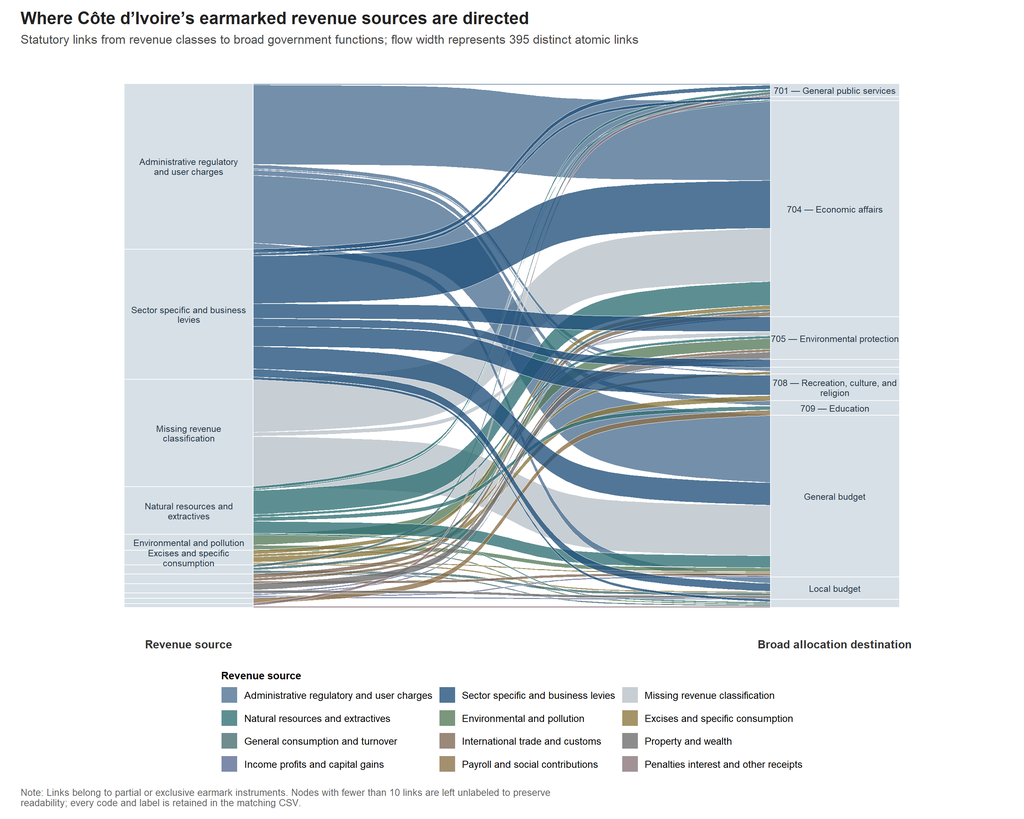

```r
civ_division_sankey_plot <- make_sankey_plot(
  civ_division_sankey_data,
  "division"
)
```

## 8.2 Revenue class to four-digit destination

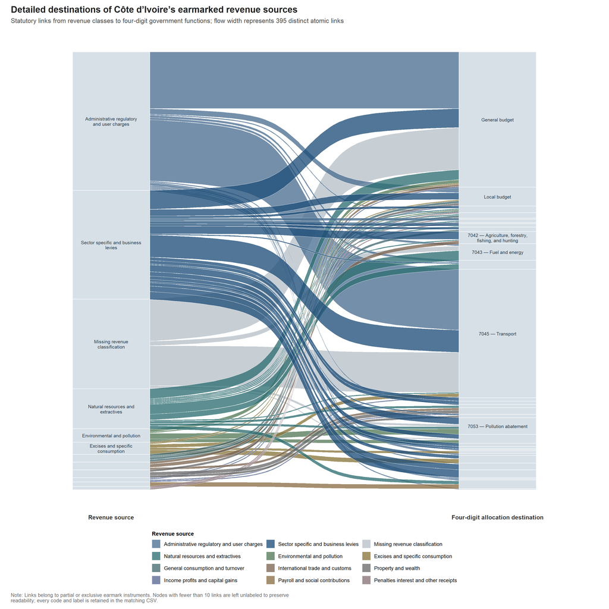

```r
civ_cofog4_sankey_plot <- make_sankey_plot(
  civ_cofog4_sankey_data,
  "cofog4"
)
```

## 8.3 Four-digit heatmap

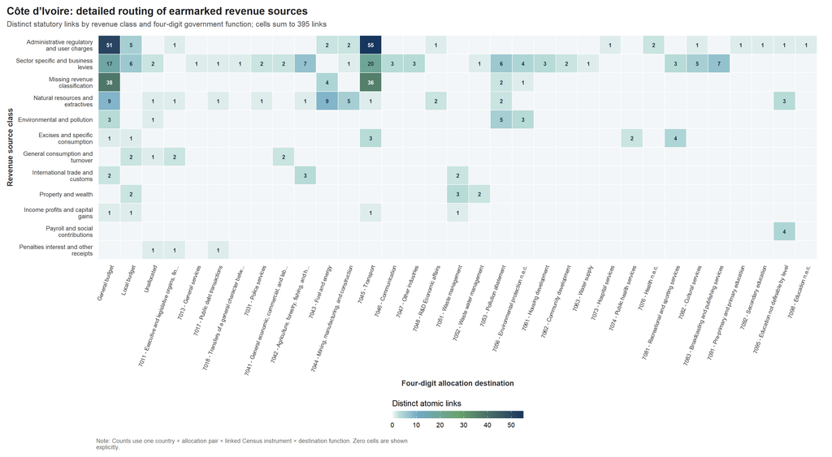

```r
civ_cofog4_heatmap_plot <- make_heatmap_plot(
  civ_cofog4_heatmap_data,
  "cofog4"
)
```

## 8.4 Division heatmap

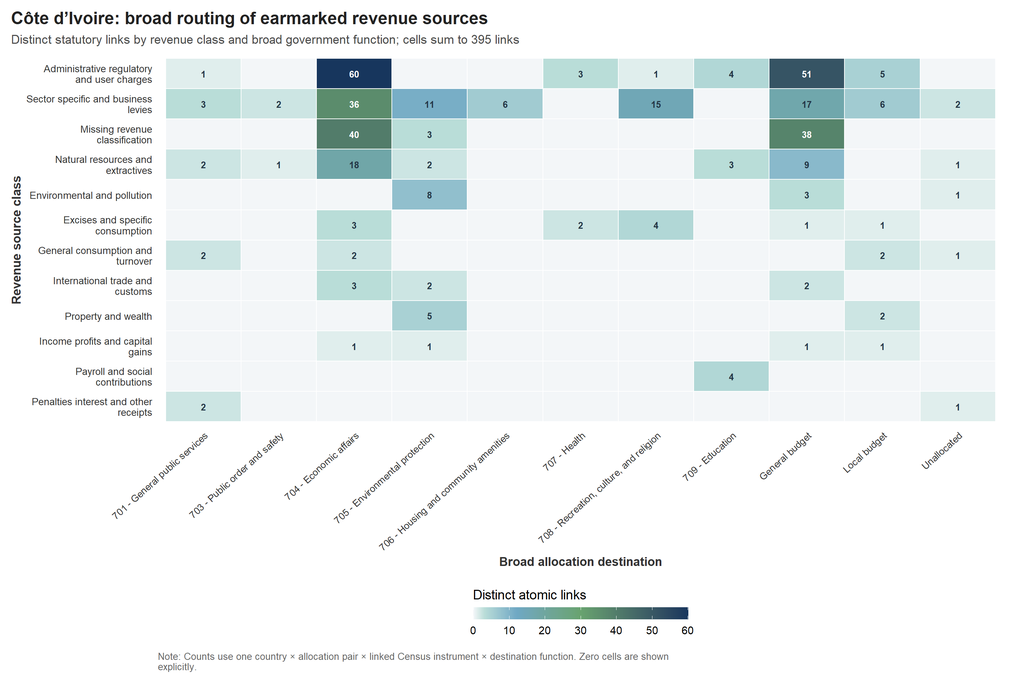

```r
civ_division_heatmap_plot <- make_heatmap_plot(
  civ_division_heatmap_data,
  "division"
)
```

# 9. Cameroon figures

## 9.1 Revenue class to broad destination

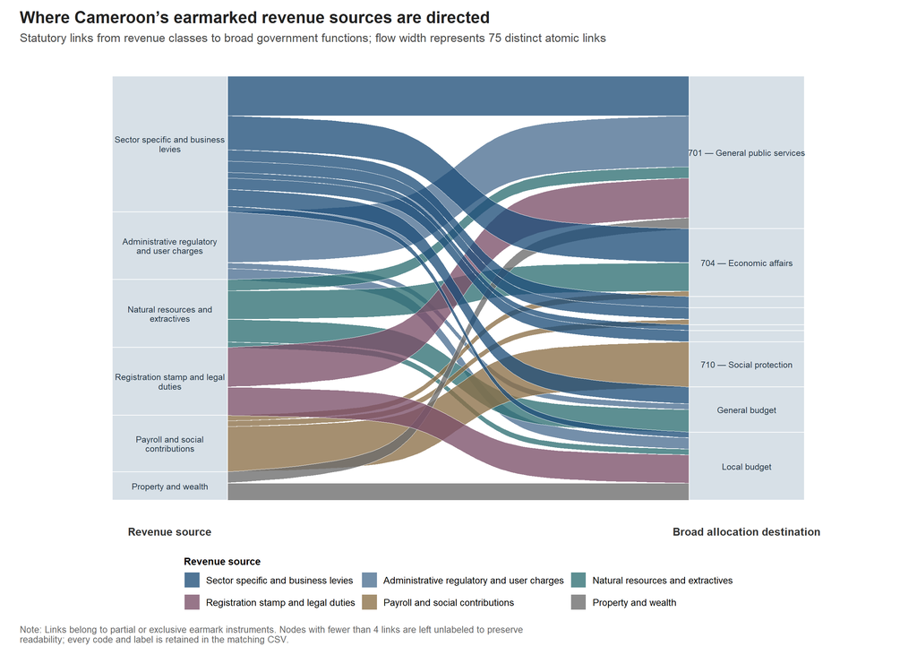

```r
cmr_division_sankey_plot <- make_sankey_plot(
  cmr_division_sankey_data,
  "division"
)
```

## 9.2 Revenue class to four-digit destination

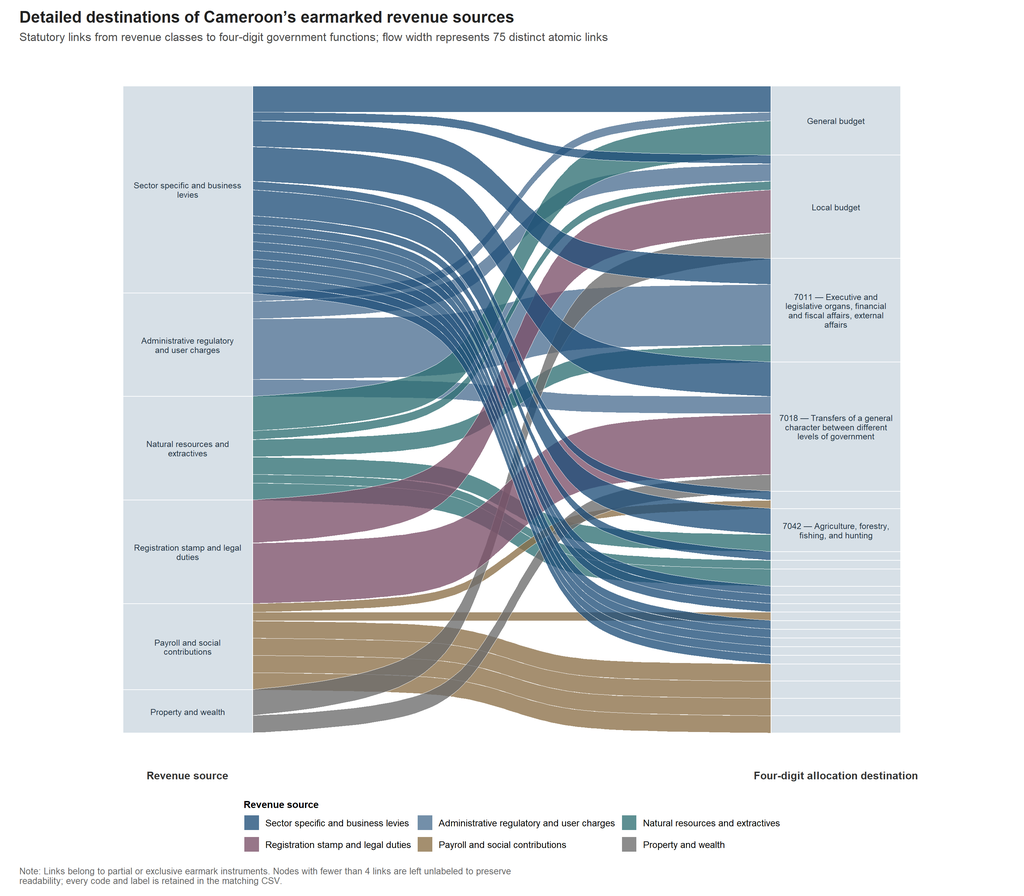

```r
cmr_cofog4_sankey_plot <- make_sankey_plot(
  cmr_cofog4_sankey_data,
  "cofog4"
)
```

## 9.3 Four-digit heatmap

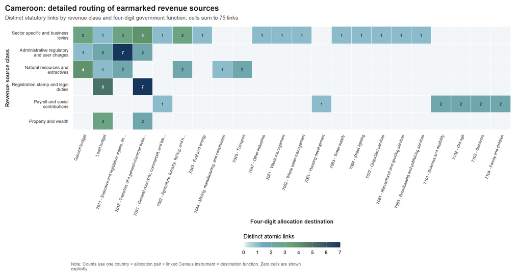

```r
cmr_cofog4_heatmap_plot <- make_heatmap_plot(
  cmr_cofog4_heatmap_data,
  "cofog4"
)
```

## 9.4 Division heatmap

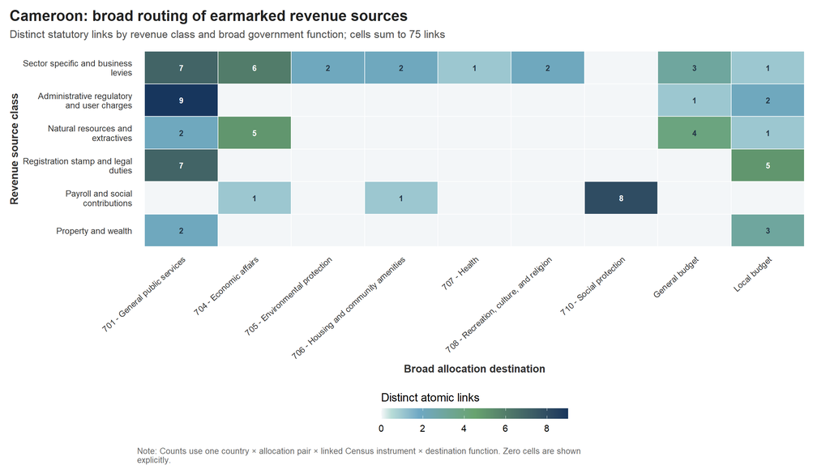

```r
cmr_division_heatmap_plot <- make_heatmap_plot(
  cmr_division_heatmap_data,
  "division"
)
```

# 10. Stage, verify, and commit outputs

Each PNG and its exact aggregated CSV are written to temporary paths first. All sixteen files are committed together only after count, value, and image checks pass.

```r
output_data <- list(
  `09_civ_revenue_to_division_sankey` = civ_division_sankey_data,
  `09_civ_revenue_to_cofog4_sankey` = civ_cofog4_sankey_data,
  `09_civ_revenue_to_cofog4_heatmap` = civ_cofog4_heatmap_data,
  `09_civ_revenue_to_division_heatmap` = civ_division_heatmap_data,
  `09_cmr_revenue_to_division_sankey` = cmr_division_sankey_data,
  `09_cmr_revenue_to_cofog4_sankey` = cmr_cofog4_sankey_data,
  `09_cmr_revenue_to_cofog4_heatmap` = cmr_cofog4_heatmap_data,
  `09_cmr_revenue_to_division_heatmap` = cmr_division_heatmap_data
)

output_plots <- list(
  `09_civ_revenue_to_division_sankey` = civ_division_sankey_plot,
  `09_civ_revenue_to_cofog4_sankey` = civ_cofog4_sankey_plot,
  `09_civ_revenue_to_cofog4_heatmap` = civ_cofog4_heatmap_plot,
  `09_civ_revenue_to_division_heatmap` = civ_division_heatmap_plot,
  `09_cmr_revenue_to_division_sankey` = cmr_division_sankey_plot,
  `09_cmr_revenue_to_cofog4_sankey` = cmr_cofog4_sankey_plot,
  `09_cmr_revenue_to_cofog4_heatmap` = cmr_cofog4_heatmap_plot,
  `09_cmr_revenue_to_division_heatmap` = cmr_division_heatmap_plot
)

plot_dimensions <- tribble(
  ~stem, ~width, ~height,
  "09_civ_revenue_to_division_sankey", 15, 12,
  "09_civ_revenue_to_cofog4_sankey", 17, 17,
  "09_civ_revenue_to_cofog4_heatmap", 20, 11,
  "09_civ_revenue_to_division_heatmap", 15, 10,
  "09_cmr_revenue_to_division_sankey", 14, 10,
  "09_cmr_revenue_to_cofog4_sankey", 16, 14,
  "09_cmr_revenue_to_cofog4_heatmap", 17, 9,
  "09_cmr_revenue_to_division_heatmap", 14, 8
)

csv_output_paths <- set_names(
  file.path(table_dir, paste0(names(output_data), ".csv")),
  names(output_data)
)
png_output_paths <- set_names(
  file.path(figure_dir, paste0(names(output_plots), ".png")),
  names(output_plots)
)
all_output_paths <- c(
  set_names(unname(csv_output_paths), paste0(names(csv_output_paths), "_csv")),
  set_names(unname(png_output_paths), paste0(names(png_output_paths), "_png"))
)
```

```r
stage_dir <- tempfile(pattern = "09_country_focus_stage_")
dir.create(stage_dir, recursive = TRUE, showWarnings = FALSE)

stage_csv_paths <- set_names(
  file.path(stage_dir, paste0(names(output_data), ".csv")),
  names(output_data)
)
stage_png_paths <- set_names(
  file.path(stage_dir, paste0(names(output_plots), ".png")),
  names(output_plots)
)
stage_output_paths <- c(
  set_names(unname(stage_csv_paths), paste0(names(stage_csv_paths), "_csv")),
  set_names(unname(stage_png_paths), paste0(names(stage_png_paths), "_png"))
)

iwalk(output_data, function(data, stem) {
  write_csv(data, stage_csv_paths[[stem]], na = "")
})

iwalk(output_plots, function(plot_object, stem) {
  dimensions <- plot_dimensions %>% filter(.data$stem == .env$stem)
  ggsave(
    filename = stage_png_paths[[stem]],
    plot = plot_object,
    width = dimensions$width,
    height = dimensions$height,
    units = "in",
    dpi = 300,
    bg = "white"
  )
})

same_table_values <- function(saved, expected) {
  expected_as_text <- expected %>%
    mutate(across(everything(), as.character))

  identical(names(saved), names(expected)) &&
    nrow(saved) == nrow(expected) &&
    identical(as.data.frame(saved), as.data.frame(expected_as_text))
}

staged_csv_checks <- imap_dfr(output_data, function(expected, stem) {
  saved <- read_csv(
    stage_csv_paths[[stem]],
    col_types = cols(.default = col_character()),
    show_col_types = FALSE,
    progress = FALSE
  )
  tibble(
    output = paste0(stem, ".csv"),
    rows = nrow(saved),
    passed = same_table_values(saved, expected)
  )
})

staged_png_checks <- imap_dfr(output_plots, function(plot_object, stem) {
  tibble(
    output = paste0(stem, ".png"),
    bytes = file.info(stage_png_paths[[stem]])$size,
    passed = file.exists(stage_png_paths[[stem]]) &&
      file.info(stage_png_paths[[stem]])$size > 10000
  )
})

if (!all(staged_csv_checks$passed) || !all(staged_png_checks$passed)) {
  print(staged_csv_checks %>% filter(!passed))
  print(staged_png_checks %>% filter(!passed))
  stop("Staged plot-data or figure checks failed; no final output was written.")
}
```

```r
commit_output_bundle <- function(stage_paths, final_paths) {
  existed_before <- set_names(file.exists(final_paths), names(final_paths))
  backup_dir <- tempfile(pattern = "09_country_focus_backup_")
  dir.create(backup_dir, recursive = TRUE, showWarnings = FALSE)
  backup_paths <- file.path(backup_dir, basename(final_paths))
  names(backup_paths) <- names(final_paths)
  committed <- FALSE

  on.exit({
    if (!committed) {
      for (name in names(final_paths)) {
        if (existed_before[[name]] && file.exists(backup_paths[[name]])) {
          file.copy(
            backup_paths[[name]],
            final_paths[[name]],
            overwrite = TRUE
          )
        } else if (!existed_before[[name]] &&
                   file.exists(final_paths[[name]])) {
          file.remove(final_paths[[name]])
        }
      }
    }
    unlink(stage_dir, recursive = TRUE, force = TRUE)
    unlink(backup_dir, recursive = TRUE, force = TRUE)
  }, add = TRUE)

  for (name in names(final_paths)[existed_before]) {
    if (!file.copy(
      final_paths[[name]],
      backup_paths[[name]],
      overwrite = FALSE
    )) {
      stop("Could not create a rollback copy for ", name, ".")
    }
  }

  commit_ok <- vapply(
    names(final_paths),
    function(name) file.copy(
      stage_paths[[name]],
      final_paths[[name]],
      overwrite = TRUE
    ),
    logical(1)
  )
  if (!all(commit_ok)) {
    stop("Could not commit every requested country-focus output.")
  }

  final_csv_checks <- imap_dfr(output_data, function(expected, stem) {
    saved <- read_csv(
      csv_output_paths[[stem]],
      col_types = cols(.default = col_character()),
      show_col_types = FALSE,
      progress = FALSE
    )
    tibble(
      output = paste0(stem, ".csv"),
      rows = nrow(saved),
      passed = same_table_values(saved, expected)
    )
  })

  final_png_checks <- imap_dfr(output_plots, function(plot_object, stem) {
    tibble(
      output = paste0(stem, ".png"),
      bytes = file.info(png_output_paths[[stem]])$size,
      passed = file.exists(png_output_paths[[stem]]) &&
        file.info(png_output_paths[[stem]])$size > 10000
    )
  })

  if (!all(final_csv_checks$passed) || !all(final_png_checks$passed)) {
    print(final_csv_checks %>% filter(!passed))
    print(final_png_checks %>% filter(!passed))
    stop("Final read-back checks failed; restoring prior outputs.")
  }

  committed <- TRUE
  list(csv_checks = final_csv_checks, png_checks = final_png_checks)
}

committed_outputs <- commit_output_bundle(
  stage_output_paths,
  all_output_paths
)

input_md5_after <- unname(tools::md5sum(input_paths))
input_integrity_check <- tibble(
  input = names(input_paths),
  md5_before = input_md5_before,
  md5_after = input_md5_after,
  unchanged = input_md5_before == input_md5_after
)
if (!all(input_integrity_check$unchanged)) {
  print(input_integrity_check)
  stop("An input file changed during the analysis run.")
}
```

```r
display_table(committed_outputs$csv_checks)
```

```
##
##
## |output                                 | rows|passed |
## |:--------------------------------------|----:|:------|
## |09_civ_revenue_to_division_sankey.csv  |   50|TRUE   |
## |09_civ_revenue_to_cofog4_sankey.csv    |   80|TRUE   |
## |09_civ_revenue_to_cofog4_heatmap.csv   |  396|TRUE   |
## |09_civ_revenue_to_division_heatmap.csv |  132|TRUE   |
## |09_cmr_revenue_to_division_sankey.csv  |   22|TRUE   |
## |09_cmr_revenue_to_cofog4_sankey.csv    |   35|TRUE   |
## |09_cmr_revenue_to_cofog4_heatmap.csv   |  132|TRUE   |
## |09_cmr_revenue_to_division_heatmap.csv |   54|TRUE   |
```

```r
display_table(committed_outputs$png_checks)
```

```
##
##
## |output                                 |  bytes|passed |
## |:--------------------------------------|------:|:------|
## |09_civ_revenue_to_division_sankey.png  | 382562|TRUE   |
## |09_civ_revenue_to_cofog4_sankey.png    | 614174|TRUE   |
## |09_civ_revenue_to_cofog4_heatmap.png   | 398685|TRUE   |
## |09_civ_revenue_to_division_heatmap.png | 259017|TRUE   |
## |09_cmr_revenue_to_division_sankey.png  | 253736|TRUE   |
## |09_cmr_revenue_to_cofog4_sankey.png    | 380959|TRUE   |
## |09_cmr_revenue_to_cofog4_heatmap.png   | 276517|TRUE   |
## |09_cmr_revenue_to_division_heatmap.png | 187024|TRUE   |
```

```r
display_table(input_integrity_check)
```

```
##
##
## |input         |md5_before                       |md5_after                        |unchanged |
## |:-------------|:--------------------------------|:--------------------------------|:---------|
## |expanded      |1f770e2e5096fb09506bccc69a2cf5f1 |1f770e2e5096fb09506bccc69a2cf5f1 |TRUE      |
## |cofog_mapping |32093253739a8b9c384c6d80d8dcd4e3 |32093253739a8b9c384c6d80d8dcd4e3 |TRUE      |
```

# 11. Run summary

```r
cat(
  "- Countries included: C\u00f4te d\u2019Ivoire (CIV) and Cameroon (CMR).\n",
  "- Filter: allocation-source `earmark_status` is partial or exclusive earmark; no other analytical filter was applied.\n",
  "- CIV: ",
  country_checks$n_source_revenue_classes[country_checks$country == "CIV"],
  " displayed revenue classes, ",
  country_checks$n_distinct_pair_id[country_checks$country == "CIV"],
  " allocation pairs, and ",
  country_checks$n_atomic_links[country_checks$country == "CIV"],
  " function-expanded atomic links.\n",
  "- CMR: ",
  country_checks$n_source_revenue_classes[country_checks$country == "CMR"],
  " displayed revenue classes, ",
  country_checks$n_distinct_pair_id[country_checks$country == "CMR"],
  " allocation pairs, and ",
  country_checks$n_atomic_links[country_checks$country == "CMR"],
  " function-expanded atomic links.\n",
  "- Missing revenue classification: 81 CIV links and 0 CMR links.\n",
  "- Unmapped destination-function codes: ",
  nrow(unmapped_destination_functions), ".\n",
  "- Duplicate atomic-link candidates removed: ",
  sum(country_checks$duplicate_atomic_link_keys_removed), ".\n",
  "- Outputs created: 8 matching CSV/PNG pairs.\n",
  sep = ""
)
```

- Countries included: Côte d’Ivoire (CIV) and Cameroon (CMR).
- Filter: allocation-source `earmark_status` is partial or exclusive earmark; no other analytical filter was applied.
- CIV: 12 displayed revenue classes, 153 allocation pairs, and 395 function-expanded atomic links.
- CMR: 6 displayed revenue classes, 50 allocation pairs, and 75 function-expanded atomic links.
- Missing revenue classification: 81 CIV links and 0 CMR links.
- Unmapped destination-function codes: 0.
- Duplicate atomic-link candidates removed: 0.
- Outputs created: 8 matching CSV/PNG pairs.